# Decision Trees

Kim Pham

11/14/2017

## 0. Load libraries

```r
library(rpart)
library(party)
library(dplyr)
```

## 1. Upload data file

Data file description: This data is from the Assistments Intelligent Tutoring system. This system gives students hints based on how they perform on math problems.

Codebook

id - student id prior_prob_count - The number of problems a student has done in the system prior to the surrent session prior_percent_correct - The percentage of problems a student has gotten correct in the system prior to the surrent session score - The score the student achieved in the current session hints - The number of hints the student requested in the current session hint.y - Whether or not the student asked for hints in the current session complete - Whether or not the student completed the current session action - The action suggested by the system to a teacher about a given student based on their performance

```r
df <- read.csv("Data/intelligent_tutor.csv")
```

## 2. Build Classificaiton Tree

Goal: Predict which students ask a teacher for help, which start a new session, or which give up, based on whether or not the student completed a session (df$complete) and whether or not they asked for hints (df$hint.y).

```r
c.tree <- rpart(action ~ hint.y + complete, method="class", data=df)
printcp(c.tree) # tree error
```

```
##
## Classification tree:
## rpart(formula = action ~ hint.y + complete, data = df, method = "class")
##
## Variables actually used in tree construction:
## [1] complete hint.y
##
## Root node error: 250/378 = 0.66138
##
## n= 378
##
##      CP nsplit rel error xerror     xstd
## 1 0.052      0     1.000  1.096 0.034730
## 2 0.012      1     0.948  1.072 0.035325
## 3 0.010      2     0.936  1.044 0.035952
```

```r
# Plot the tree
post(c.tree, file = "tree.ps", title = "Session Completion Action: 1 - Ask teacher, 2 - Start new session, 3 - Give up")

c.tree
```

```
## n= 378
##
## node), split, n, loss, yval, (yprob)
##       * denotes terminal node
##
## 1) root 378 250 2 (0.3227513 0.3386243 0.3386243)
##   2) complete< 0.5 174 109 1 (0.3735632 0.3275862 0.2988506) *
##   3) complete>=0.5 204 128 3 (0.2794118 0.3480392 0.3725490)
##     6) hint.y>=0.5 97  62 2 (0.3092784 0.3608247 0.3298969) *
##     7) hint.y< 0.5 107  63 3 (0.2523364 0.3364486 0.4112150) *
```

## 3. Build Regression Tree

Goal: We want to see if we can build a decision tree to help teachers decide which students to follow up with, based on students’ performance in Assistments.

- We will create three groups (“teacher should intervene”, “teacher should monitor student progress” and “no action”) based on students’ previous use of the system and how many hints they use.
- To do this we will be building a decision tree using the “party” package. The party package builds decision trees based on a set of statistical stopping rules.

#### Take a look at our outcome variable “score”

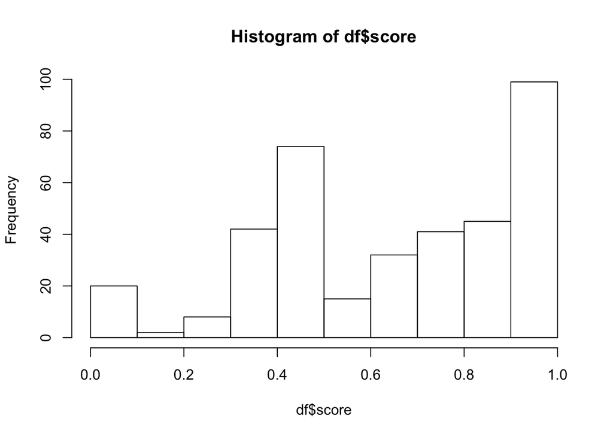

```r
hist(df$score)
```

#### Create a categorical outcome variable based on student score to advise the teacher using an “ifelse” statement

```r
df$advice <- ifelse(df$score <=0.4, "intervene", ifelse(df$score > 0.4 & df$score <=0.8, "monitor", "no action"))
```

#### Build a decision tree that predicts “advice” based on how many problems students have answered before, the percentage of those problems they got correct and how many hints they required

```r
score_ctree <- ctree(factor(advice) ~ prior_prob_count + prior_percent_correct + hints, df)
```

#### Plot tree

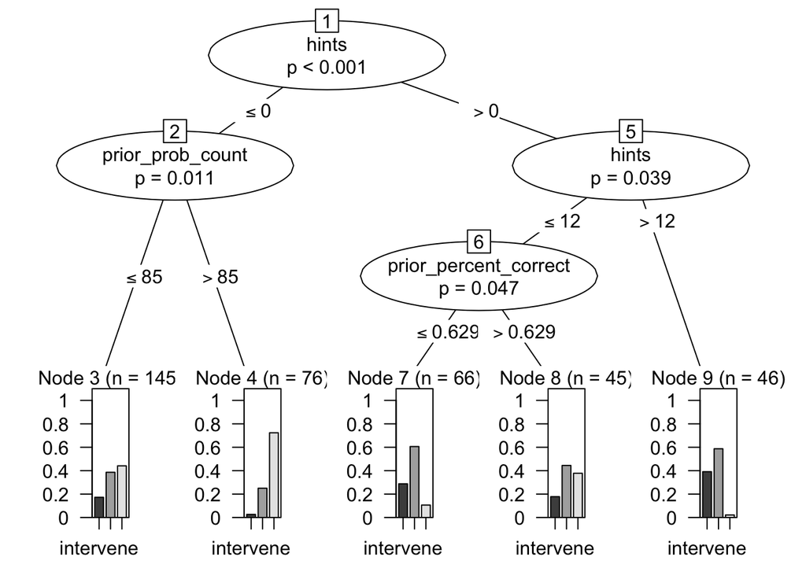

```r
plot(score_ctree)
```

## 5. Test Tree

#### Upload new data set

This is a data set of a different sample of students doing the same problems in the same system. We can use the tree we built for the previous data set to try to predict the “advice” we should give the teacher about these new students.

```r
df2 <- read.csv("Data/intelligent_tutor_new.csv")
```

#### Predict advice for new students from tree model

```r
df2$prediction <- predict(score_ctree, df2)
```

#### Analyze Test Results

Since we do not know the actual advice the new students received, we cannot compare predicted versus actual results. However, we can investigate patterns of the predictions. For example, it seems the tree model advises the students to be monitored if they have asked for at least 1 hint.

A limitation of the predictions on the new students is all students passed with a score of 1. While there was no predicted result which advised the teacher to ‘intervene’ with a student, there were some students that teachers were advised to ‘monitor’ (n=84). Maybe the monitoring was not necessary if the students passed.

```r
df2 %>% group_by(prediction) %>% count()
```

```
## # A tibble: 2 x 2
## # Groups:   prediction [2]
##   prediction     n
##   <fct>      <int>
## 1 monitor       84
## 2 no action    116
```